# import libraries

```python
import pandas as pd
import seaborn as sns

# 2 line for html export
import plotly.io as pio
pio.renderers.default ='notebook'

# 2 lines below for PDF export
!pip install pyppeteer
!pyppeteer-install
```

```python
df = pd.read_csv('TWO_CENTURIES_OF_UM_RACES.csv')
```

# visualize the imported data

```python
df
```

|  | Year of event | Event dates | Event name | Event distance/length | Event number of finishers | Athlete performance | Athlete club | Athlete country | Athlete year of birth | Athlete gender | Athlete age category | Athlete average speed | Athlete ID |
| --- | --- | --- | --- | --- | --- | --- | --- | --- | --- | --- | --- | --- | --- |
| 0 | 2018 | 06.01.2018 | Selva Costera (CHI) | 50km | 22 | 4:51:39 h | Tnfrc | CHI | 1978.0 | M | M35 | 10.286 | 0 |
| 1 | 2018 | 06.01.2018 | Selva Costera (CHI) | 50km | 22 | 5:15:45 h | Roberto Echeverría | CHI | 1981.0 | M | M35 | 9.501 | 1 |
| 2 | 2018 | 06.01.2018 | Selva Costera (CHI) | 50km | 22 | 5:16:44 h | Puro Trail Osorno | CHI | 1987.0 | M | M23 | 9.472 | 2 |
| 3 | 2018 | 06.01.2018 | Selva Costera (CHI) | 50km | 22 | 5:34:13 h | Columbia | ARG | 1976.0 | M | M40 | 8.976 | 3 |
| 4 | 2018 | 06.01.2018 | Selva Costera (CHI) | 50km | 22 | 5:54:14 h | Baguales Trail | CHI | 1992.0 | M | M23 | 8.469 | 4 |
| ... | ... | ... | ... | ... | ... | ... | ... | ... | ... | ... | ... | ... | ... |
| 7461190 | 1995 | 00.00.1995 | La SainteLyon 65 km (FRA) | 65km | 2 | 4:33:20 h | NaN | FRA | NaN | M | NaN | 14268.0 | 1151060 |
| 7461191 | 1995 | 00.00.1995 | La SainteLyon 65 km (FRA) | 65km | 2 | 6:05:15 h | NaN | FRA | NaN | F | NaN | 10678.0 | 1073520 |
| 7461192 | 1995 | 00.00.1995 | Szombathely 24 hours running Race (HUN) | 24h | 3 | 241.000 km | *Budapest | HUN | 1950.0 | M | M40 | 10042.0 | 1047373 |
| 7461193 | 1995 | 00.00.1995 | Szombathely 24 hours running Race (HUN) | 24h | 3 | 228.000 km | *Szeged | HUN | 1959.0 | M | M35 | 9500.0 | 380150 |
| 7461194 | 1995 | 00.00.1995 | Szombathely 24 hours running Race (HUN) | 24h | 3 | 224.000 km | *Pecs | HUN | 1958.0 | M | M35 | 9333.0 | 1070482 |

7461195 rows × 13 columns

```python
df.shape
```

```
(7461195, 13)
```

```python
#check column types
```

```python
df.dtypes
```

```
Year of event                  int64
Event dates                   object
Event name                    object
Event distance/length         object
Event number of finishers      int64
Athlete performance           object
Athlete club                  object
Athlete country               object
Athlete year of birth        float64
Athlete gender                object
Athlete age category          object
Athlete average speed         object
Athlete ID                     int64
dtype: object
```

# Clean and analyze races 50Km and 50mi, that happen in 'USA' year 2020

```
check if there's race specified as: 50k,50m,50km etc.
```

```python
df["Event distance/length"].unique()
```

```
array(['50km', '6h', '63.9km', ..., '2925.7mi/64Etappen',
       '355km/5Etappen', '2906.1mi/64Etappen'], dtype=object)
```

```python
df[df["Event distance/length"]== '50mi'].head()
```

|  | Year of event | Event dates | Event name | Event distance/length | Event number of finishers | Athlete performance | Athlete club | Athlete country | Athlete year of birth | Athlete gender | Athlete age category | Athlete average speed | Athlete ID |
| --- | --- | --- | --- | --- | --- | --- | --- | --- | --- | --- | --- | --- | --- |
| 55 | 2018 | 06.01.2018 | Yankee Springs 50 Mile Winter Challenge (USA) | 50mi | 9 | 9:53:05 h | *Middleville, MI | USA | 1983.0 | M | M23 | 8.141 | 55 |
| 56 | 2018 | 06.01.2018 | Yankee Springs 50 Mile Winter Challenge (USA) | 50mi | 9 | 11:09:35 h | *Waterloo, ON | CAN | 1977.0 | F | W40 | 7.211 | 56 |
| 57 | 2018 | 06.01.2018 | Yankee Springs 50 Mile Winter Challenge (USA) | 50mi | 9 | 11:33:00 h | *Kitchener, ON | CAN | 1976.0 | M | M40 | 6.967 | 57 |
| 58 | 2018 | 06.01.2018 | Yankee Springs 50 Mile Winter Challenge (USA) | 50mi | 9 | 11:38:17 h | *Utica, MI | USA | 1986.0 | M | M23 | 6.914 | 58 |
| 59 | 2018 | 06.01.2018 | Yankee Springs 50 Mile Winter Challenge (USA) | 50mi | 9 | 11:56:35 h | *Grass Lake, MI | USA | 1988.0 | M | M23 | 6.738 | 59 |

# combine 50k and 50mi and filter year of event

```python
df[(df["Event distance/length"].isin(['50km','50mi'])) & (df['Year of event'] == 2020)]
```

|  | Year of event | Event dates | Event name | Event distance/length | Event number of finishers | Athlete performance | Athlete club | Athlete country | Athlete year of birth | Athlete gender | Athlete age category | Athlete average speed | Athlete ID |
| --- | --- | --- | --- | --- | --- | --- | --- | --- | --- | --- | --- | --- | --- |
| 2538571 | 2020 | 07.-09.02.2020 | Taipei 48hr Ultra Marathon - 50mi (TPE) | 50mi | 38 | 7:34:19 h | 日本隊 | JPN | 1965.0 | M | M50 | 10.627 | 53107 |
| 2538572 | 2020 | 07.-09.02.2020 | Taipei 48hr Ultra Marathon - 50mi (TPE) | 50mi | 38 | 7:43:50 h | NaN | AUS | 1974.0 | M | M45 | 10.409 | 8785 |
| 2538573 | 2020 | 07.-09.02.2020 | Taipei 48hr Ultra Marathon - 50mi (TPE) | 50mi | 38 | 8:04:40 h | NaN | TPE | 1976.0 | M | M40 | 9.962 | 4502 |
| 2538574 | 2020 | 07.-09.02.2020 | Taipei 48hr Ultra Marathon - 50mi (TPE) | 50mi | 38 | 8:30:49 h | 台灣大腳ㄚ長跑協會 | TPE | 1969.0 | F | W50 | 9.452 | 63964 |
| 2538575 | 2020 | 07.-09.02.2020 | Taipei 48hr Ultra Marathon - 50mi (TPE) | 50mi | 38 | 8:34:47 h | NaN | TPE | 1964.0 | M | M55 | 9.379 | 4485 |
| ... | ... | ... | ... | ... | ... | ... | ... | ... | ... | ... | ... | ... | ... |
| 2762404 | 2020 | 03.10.2020 | Bison Ultra-Trail 50 (POL) | 50km | 271 | 7:36:25 h | AKS Polonia Warszawa | POL | 1981.0 | F | W35 | 6.573 | 860743 |
| 2762405 | 2020 | 03.10.2020 | Bison Ultra-Trail 50 (POL) | 50km | 271 | 7:36:27 h | *Warszawa | POL | 1970.0 | F | W45 | 6.572 | 860744 |
| 2762406 | 2020 | 03.10.2020 | Bison Ultra-Trail 50 (POL) | 50km | 271 | 7:44:18 h | Outdoor Training | POL | 1993.0 | F | W23 | 6.461 | 860745 |
| 2762407 | 2020 | 03.10.2020 | Bison Ultra-Trail 50 (POL) | 50km | 271 | 8:04:50 h | PH Bysewo Gdańsk | POL | 1976.0 | M | M40 | 6.188 | 798409 |
| 2762408 | 2020 | 03.10.2020 | Bison Ultra-Trail 50 (POL) | 50km | 271 | 8:11:43 h | *Nowe Aleksandrowo | POL | 1961.0 | M | M55 | 6.101 | 860746 |

63489 rows × 13 columns

```python
df.head()
```

[output not shown]

```python
#combine all the filters together
```

```python
usa_races = df[(df["Event distance/length"].isin(['50km','50mi'])) & (df['Year of event'] == 2020) & (df["Event name"].str.split('(').str.get(1).str.split(')').str.get(0) == 'USA')]
usa_races.head()
```

|  | Year of event | Event dates | Event name | Event distance/length | Event number of finishers | Athlete performance | Athlete club | Athlete country | Athlete year of birth | Athlete gender | Athlete age category | Athlete average speed | Athlete ID |
| --- | --- | --- | --- | --- | --- | --- | --- | --- | --- | --- | --- | --- | --- |
| 2539945 | 2020 | 02.02.2020 | West Seattle Beach Run - Winter Edition (USA) | 50km | 20 | 3:17:55 h | *Normandy Park, WA | USA | 1991.0 | M | M23 | 15.158 | 71287 |
| 2539946 | 2020 | 02.02.2020 | West Seattle Beach Run - Winter Edition (USA) | 50km | 20 | 4:02:32 h | *Gold Bar, WA | USA | 1981.0 | M | M35 | 12.369 | 629508 |
| 2539947 | 2020 | 02.02.2020 | West Seattle Beach Run - Winter Edition (USA) | 50km | 20 | 4:07:57 h | *Vashon, WA | USA | 1999.0 | M | MU23 | 12.099 | 64838 |
| 2539948 | 2020 | 02.02.2020 | West Seattle Beach Run - Winter Edition (USA) | 50km | 20 | 4:22:02 h | *Gig Harbor, WA | USA | 1983.0 | M | M35 | 11.449 | 704450 |
| 2539949 | 2020 | 02.02.2020 | West Seattle Beach Run - Winter Edition (USA) | 50km | 20 | 4:27:34 h | *Bainbridge Island, WA | USA | 1977.0 | M | M40 | 11.212 | 810281 |

```python
usa_races.shape
```

```
(26090, 13)
```

# remove (USA) from event name

.split on '(' and get zero object after that

```python
usa_races['Event name'].str.split('(').str.get(0)
```

```
2539945    West Seattle Beach Run - Winter Edition
2539946    West Seattle Beach Run - Winter Edition
2539947    West Seattle Beach Run - Winter Edition
2539948    West Seattle Beach Run - Winter Edition
2539949    West Seattle Beach Run - Winter Edition
                             ...
2760957     Yankee Springs Fall Trail Run Festival
2760958     Yankee Springs Fall Trail Run Festival
2760959     Yankee Springs Fall Trail Run Festival
2760960     Yankee Springs Fall Trail Run Festival
2760961     Yankee Springs Fall Trail Run Festival
Name: Event name, Length: 26090, dtype: object
```

```python
usa_races['Event name'] = usa_races['Event name'].str.split('(').str.get(0)
usa_races.head()
```

|  | Year of event | Event dates | Event name | Event distance/length | Event number of finishers | Athlete performance | Athlete club | Athlete country | Athlete year of birth | Athlete gender | Athlete age category | Athlete average speed | Athlete ID |
| --- | --- | --- | --- | --- | --- | --- | --- | --- | --- | --- | --- | --- | --- |
| 2539945 | 2020 | 02.02.2020 | West Seattle Beach Run - Winter Edition | 50km | 20 | 3:17:55 h | *Normandy Park, WA | USA | 1991.0 | M | M23 | 15.158 | 71287 |
| 2539946 | 2020 | 02.02.2020 | West Seattle Beach Run - Winter Edition | 50km | 20 | 4:02:32 h | *Gold Bar, WA | USA | 1981.0 | M | M35 | 12.369 | 629508 |
| 2539947 | 2020 | 02.02.2020 | West Seattle Beach Run - Winter Edition | 50km | 20 | 4:07:57 h | *Vashon, WA | USA | 1999.0 | M | MU23 | 12.099 | 64838 |
| 2539948 | 2020 | 02.02.2020 | West Seattle Beach Run - Winter Edition | 50km | 20 | 4:22:02 h | *Gig Harbor, WA | USA | 1983.0 | M | M35 | 11.449 | 704450 |
| 2539949 | 2020 | 02.02.2020 | West Seattle Beach Run - Winter Edition | 50km | 20 | 4:27:34 h | *Bainbridge Island, WA | USA | 1977.0 | M | M40 | 11.212 | 810281 |

# Create athlete age column

```python
usa_races['Athlete age'] = 2020 - usa_races['Athlete year of birth']
```

```python
usa_races.head()
```

|  | Year of event | Event dates | Event name | Event distance/length | Event number of finishers | Athlete performance | Athlete club | Athlete country | Athlete year of birth | Athlete gender | Athlete age category | Athlete average speed | Athlete ID | Athlete age |
| --- | --- | --- | --- | --- | --- | --- | --- | --- | --- | --- | --- | --- | --- | --- |
| 2539945 | 2020 | 02.02.2020 | West Seattle Beach Run - Winter Edition | 50km | 20 | 3:17:55 h | *Normandy Park, WA | USA | 1991.0 | M | M23 | 15.158 | 71287 | 29.0 |
| 2539946 | 2020 | 02.02.2020 | West Seattle Beach Run - Winter Edition | 50km | 20 | 4:02:32 h | *Gold Bar, WA | USA | 1981.0 | M | M35 | 12.369 | 629508 | 39.0 |
| 2539947 | 2020 | 02.02.2020 | West Seattle Beach Run - Winter Edition | 50km | 20 | 4:07:57 h | *Vashon, WA | USA | 1999.0 | M | MU23 | 12.099 | 64838 | 21.0 |
| 2539948 | 2020 | 02.02.2020 | West Seattle Beach Run - Winter Edition | 50km | 20 | 4:22:02 h | *Gig Harbor, WA | USA | 1983.0 | M | M35 | 11.449 | 704450 | 37.0 |
| 2539949 | 2020 | 02.02.2020 | West Seattle Beach Run - Winter Edition | 50km | 20 | 4:27:34 h | *Bainbridge Island, WA | USA | 1977.0 | M | M40 | 11.212 | 810281 | 43.0 |

# remove h from athlete performance

```python
usa_races['Athlete performance'] = usa_races['Athlete performance'].str.split(' ').str.get(0)
usa_races.head()
```

|  | Year of event | Event dates | Event name | Event distance/length | Event number of finishers | Athlete performance | Athlete club | Athlete country | Athlete year of birth | Athlete gender | Athlete age category | Athlete average speed | Athlete ID | Athlete age |
| --- | --- | --- | --- | --- | --- | --- | --- | --- | --- | --- | --- | --- | --- | --- |
| 2539945 | 2020 | 02.02.2020 | West Seattle Beach Run - Winter Edition | 50km | 20 | 3:17:55 | *Normandy Park, WA | USA | 1991.0 | M | M23 | 15.158 | 71287 | 29.0 |
| 2539946 | 2020 | 02.02.2020 | West Seattle Beach Run - Winter Edition | 50km | 20 | 4:02:32 | *Gold Bar, WA | USA | 1981.0 | M | M35 | 12.369 | 629508 | 39.0 |
| 2539947 | 2020 | 02.02.2020 | West Seattle Beach Run - Winter Edition | 50km | 20 | 4:07:57 | *Vashon, WA | USA | 1999.0 | M | MU23 | 12.099 | 64838 | 21.0 |
| 2539948 | 2020 | 02.02.2020 | West Seattle Beach Run - Winter Edition | 50km | 20 | 4:22:02 | *Gig Harbor, WA | USA | 1983.0 | M | M35 | 11.449 | 704450 | 37.0 |
| 2539949 | 2020 | 02.02.2020 | West Seattle Beach Run - Winter Edition | 50km | 20 | 4:27:34 | *Bainbridge Island, WA | USA | 1977.0 | M | M40 | 11.212 | 810281 | 43.0 |

```python
usa_races.to_csv("usa_races.csv")
```

```python
usa_races.head()
```

|  | Year of event | Event dates | Event name | Event distance/length | Event number of finishers | Athlete performance | Athlete club | Athlete country | Athlete year of birth | Athlete gender | Athlete age category | Athlete average speed | Athlete ID | Athlete age |
| --- | --- | --- | --- | --- | --- | --- | --- | --- | --- | --- | --- | --- | --- | --- |
| 2539945 | 2020 | 02.02.2020 | West Seattle Beach Run - Winter Edition | 50km | 20 | 3:17:55 | *Normandy Park, WA | USA | 1991.0 | M | M23 | 15.158 | 71287 | 29.0 |
| 2539946 | 2020 | 02.02.2020 | West Seattle Beach Run - Winter Edition | 50km | 20 | 4:02:32 | *Gold Bar, WA | USA | 1981.0 | M | M35 | 12.369 | 629508 | 39.0 |
| 2539947 | 2020 | 02.02.2020 | West Seattle Beach Run - Winter Edition | 50km | 20 | 4:07:57 | *Vashon, WA | USA | 1999.0 | M | MU23 | 12.099 | 64838 | 21.0 |
| 2539948 | 2020 | 02.02.2020 | West Seattle Beach Run - Winter Edition | 50km | 20 | 4:22:02 | *Gig Harbor, WA | USA | 1983.0 | M | M35 | 11.449 | 704450 | 37.0 |
| 2539949 | 2020 | 02.02.2020 | West Seattle Beach Run - Winter Edition | 50km | 20 | 4:27:34 | *Bainbridge Island, WA | USA | 1977.0 | M | M40 | 11.212 | 810281 | 43.0 |

# drop columns: Athlete year of birth, Athlete age category, Athlete country, Year of event, Athlete club.

```python
usa_races = usa_races.drop(['Athlete year of birth', 'Athlete age category', 'Athlete country', 'Year of event', 'Athlete club'], axis= 1)
```

```python
usa_races.head()
```

|  | Event dates | Event name | Event distance/length | Event number of finishers | Athlete performance | Athlete gender | Athlete average speed | Athlete ID | Athlete age |
| --- | --- | --- | --- | --- | --- | --- | --- | --- | --- |
| 2539945 | 02.02.2020 | West Seattle Beach Run - Winter Edition | 50km | 20 | 3:17:55 | M | 15.158 | 71287 | 29.0 |
| 2539946 | 02.02.2020 | West Seattle Beach Run - Winter Edition | 50km | 20 | 4:02:32 | M | 12.369 | 629508 | 39.0 |
| 2539947 | 02.02.2020 | West Seattle Beach Run - Winter Edition | 50km | 20 | 4:07:57 | M | 12.099 | 64838 | 21.0 |
| 2539948 | 02.02.2020 | West Seattle Beach Run - Winter Edition | 50km | 20 | 4:22:02 | M | 11.449 | 704450 | 37.0 |
| 2539949 | 02.02.2020 | West Seattle Beach Run - Winter Edition | 50km | 20 | 4:27:34 | M | 11.212 | 810281 | 43.0 |

# clean up null values

```python
usa_races.isna().sum()
```

```
Event dates                    0
Event name                     0
Event distance/length          0
Event number of finishers      0
Athlete performance            0
Athlete gender                 0
Athlete average speed          0
Athlete ID                     0
Athlete age                  233
dtype: int64
```

# Other option is to replace NaN with none

```
              This will automatically consider the empty fields as empty strings ''
```

df.read_csv(path , na_filter=False)

```
              If you already have the dataframe
```

df = df.replace(np.nan, '', regex=True) df = df.fillna('')

```python
# usa_races[['Athlete club','Athlete age']] = usa_races[['Athlete club','Athlete age']].fillna('')
```

```python
usa_races.isna().sum()
```

```
Event dates                    0
Event name                     0
Event distance/length          0
Event number of finishers      0
Athlete performance            0
Athlete gender                 0
Athlete average speed          0
Athlete ID                     0
Athlete age                  233
dtype: int64
```

# check for duplicates

```python
usa_races[usa_races.duplicated()==True]
```

|  | Event dates | Event name | Event distance/length | Event number of finishers | Athlete performance | Athlete gender | Athlete average speed | Athlete ID | Athlete age |
| --- | --- | --- | --- | --- | --- | --- | --- | --- | --- |

# reset index

```python
usa_races.reset_index(drop=True)
```

|  | Event dates | Event name | Event distance/length | Event number of finishers | Athlete performance | Athlete gender | Athlete average speed | Athlete ID | Athlete age |
| --- | --- | --- | --- | --- | --- | --- | --- | --- | --- |
| 0 | 02.02.2020 | West Seattle Beach Run - Winter Edition | 50km | 20 | 3:17:55 | M | 15.158 | 71287 | 29.0 |
| 1 | 02.02.2020 | West Seattle Beach Run - Winter Edition | 50km | 20 | 4:02:32 | M | 12.369 | 629508 | 39.0 |
| 2 | 02.02.2020 | West Seattle Beach Run - Winter Edition | 50km | 20 | 4:07:57 | M | 12.099 | 64838 | 21.0 |
| 3 | 02.02.2020 | West Seattle Beach Run - Winter Edition | 50km | 20 | 4:22:02 | M | 11.449 | 704450 | 37.0 |
| 4 | 02.02.2020 | West Seattle Beach Run - Winter Edition | 50km | 20 | 4:27:34 | M | 11.212 | 810281 | 43.0 |
| ... | ... | ... | ... | ... | ... | ... | ... | ... | ... |
| 26085 | 03.10.2020 | Yankee Springs Fall Trail Run Festival | 50km | 30 | 7:07:48 | F | 7.013 | 816361 | 62.0 |
| 26086 | 03.10.2020 | Yankee Springs Fall Trail Run Festival | 50km | 30 | 7:27:22 | F | 6.706 | 326469 | 43.0 |
| 26087 | 03.10.2020 | Yankee Springs Fall Trail Run Festival | 50km | 30 | 7:27:24 | F | 6.705 | 372174 | 58.0 |
| 26088 | 03.10.2020 | Yankee Springs Fall Trail Run Festival | 50km | 30 | 7:38:30 | F | 6.543 | 860349 | 39.0 |
| 26089 | 03.10.2020 | Yankee Springs Fall Trail Run Festival | 50km | 30 | 7:59:53 | M | 6.252 | 770097 | 40.0 |

26090 rows × 9 columns

# remove unwanted characters in the column

df['result'] = df['result'].str.replace(r'\D', '', regex=True).astype(int) or other type

list comprehension df['result'] = [x.lstrip('+-').rstrip('aAbBcC') for x in df['result']]

```python
#usa_races['Athlete club'] = usa_races['Athlete club'].map(lambda x: x.lstrip('*+-').rstrip('abBcC'))
```

```python
usa_races.dtypes
```

```
Event dates                   object
Event name                    object
Event distance/length         object
Event number of finishers      int64
Athlete performance           object
Athlete gender                object
Athlete average speed         object
Athlete ID                     int64
Athlete age                  float64
dtype: object
```

```python
usa_races.head()
```

|  | Event dates | Event name | Event distance/length | Event number of finishers | Athlete performance | Athlete gender | Athlete average speed | Athlete ID | Athlete age |
| --- | --- | --- | --- | --- | --- | --- | --- | --- | --- |
| 2539945 | 02.02.2020 | West Seattle Beach Run - Winter Edition | 50km | 20 | 3:17:55 | M | 15.158 | 71287 | 29.0 |
| 2539946 | 02.02.2020 | West Seattle Beach Run - Winter Edition | 50km | 20 | 4:02:32 | M | 12.369 | 629508 | 39.0 |
| 2539947 | 02.02.2020 | West Seattle Beach Run - Winter Edition | 50km | 20 | 4:07:57 | M | 12.099 | 64838 | 21.0 |
| 2539948 | 02.02.2020 | West Seattle Beach Run - Winter Edition | 50km | 20 | 4:22:02 | M | 11.449 | 704450 | 37.0 |
| 2539949 | 02.02.2020 | West Seattle Beach Run - Winter Edition | 50km | 20 | 4:27:34 | M | 11.212 | 810281 | 43.0 |

# Change columns to a proper data types

Note: usa_races['Athlete age'] = pd.to_numeric(usa_races['Athlete age'])

usa_races['Athlete age'] = usa_races['Athlete age'].astype(int)

df[["Athlete age", "b"]] = df[["Athlete age", "b"]].apply(pd.to_numeric)

df['Mycol'] = pd.to_datetime(df['Mycol']

df[["a", "b"]] = df[["a", "b"]].apply(pd.to_numeric)

```python
usa_races[['Athlete age','Event number of finishers']] = usa_races[['Athlete age','Event number of finishers']].apply(pd.to_numeric)
```

```python
usa_races['Athlete average speed'] = usa_races['Athlete average speed'].astype(float)
```

```python
usa_races.dtypes
```

```
Event dates                   object
Event name                    object
Event distance/length         object
Event number of finishers      int64
Athlete performance           object
Athlete gender                object
Athlete average speed        float64
Athlete ID                     int64
Athlete age                  float64
dtype: object
```

# Rename columns

Event dates  
Evet name  
Event distance/length  
Event number of finishers  
Athlete performance  
Athlete club  
Athlete gender  
Athlete average speed  
Athlete ID  
Athlete age

```python
usa_races = usa_races.rename(columns = {'Event dates': 'race_date',
                                                 'Event name': 'race_name',
                                                  'Event distance/length': 'race_lenght',
                                                  'Event number of finishers': 'race_number_of_finishers',
                                                  'Athlete performance': 'athlete_performance',
                                                  'Athlete gender': 'athlete_gender',
                                                  'Athlete average speed': 'athlete_average_speed',
                                                  'Athlete ID': 'athlete_id',
                                                  'Athlete age': 'athlete_age'})
```

```python
usa_races.head()
```

|  | race_date | race_name | race_lenght | race_number_of_finishers | athlete_performance | athlete_gender | athlete_average_speed | athlete_id | athlete_age |
| --- | --- | --- | --- | --- | --- | --- | --- | --- | --- |
| 2539945 | 02.02.2020 | West Seattle Beach Run - Winter Edition | 50km | 20 | 3:17:55 | M | 15.158 | 71287 | 29.0 |
| 2539946 | 02.02.2020 | West Seattle Beach Run - Winter Edition | 50km | 20 | 4:02:32 | M | 12.369 | 629508 | 39.0 |
| 2539947 | 02.02.2020 | West Seattle Beach Run - Winter Edition | 50km | 20 | 4:07:57 | M | 12.099 | 64838 | 21.0 |
| 2539948 | 02.02.2020 | West Seattle Beach Run - Winter Edition | 50km | 20 | 4:22:02 | M | 11.449 | 704450 | 37.0 |
| 2539949 | 02.02.2020 | West Seattle Beach Run - Winter Edition | 50km | 20 | 4:27:34 | M | 11.212 | 810281 | 43.0 |

# reorder columns

```python
usa_races = usa_races[['race_date', 'race_name', 'race_lenght', 'race_number_of_finishers', 'athlete_id', 'athlete_gender', 'athlete_age', 'athlete_performance', 'athlete_average_speed']]
```

```python
usa_races.head()
```

|  | race_date | race_name | race_lenght | race_number_of_finishers | athlete_id | athlete_gender | athlete_age | athlete_performance | athlete_average_speed |
| --- | --- | --- | --- | --- | --- | --- | --- | --- | --- |
| 2539945 | 02.02.2020 | West Seattle Beach Run - Winter Edition | 50km | 20 | 71287 | M | 29.0 | 3:17:55 | 15.158 |
| 2539946 | 02.02.2020 | West Seattle Beach Run - Winter Edition | 50km | 20 | 629508 | M | 39.0 | 4:02:32 | 12.369 |
| 2539947 | 02.02.2020 | West Seattle Beach Run - Winter Edition | 50km | 20 | 64838 | M | 21.0 | 4:07:57 | 12.099 |
| 2539948 | 02.02.2020 | West Seattle Beach Run - Winter Edition | 50km | 20 | 704450 | M | 37.0 | 4:22:02 | 11.449 |
| 2539949 | 02.02.2020 | West Seattle Beach Run - Winter Edition | 50km | 20 | 810281 | M | 43.0 | 4:27:34 | 11.212 |

```python
usa_races.reset_index(drop=True)
```

|  | race_date | race_name | race_lenght | race_number_of_finishers | athlete_id | athlete_gender | athlete_age | athlete_performance | athlete_average_speed |
| --- | --- | --- | --- | --- | --- | --- | --- | --- | --- |
| 0 | 02.02.2020 | West Seattle Beach Run - Winter Edition | 50km | 20 | 71287 | M | 29.0 | 3:17:55 | 15.158 |
| 1 | 02.02.2020 | West Seattle Beach Run - Winter Edition | 50km | 20 | 629508 | M | 39.0 | 4:02:32 | 12.369 |
| 2 | 02.02.2020 | West Seattle Beach Run - Winter Edition | 50km | 20 | 64838 | M | 21.0 | 4:07:57 | 12.099 |
| 3 | 02.02.2020 | West Seattle Beach Run - Winter Edition | 50km | 20 | 704450 | M | 37.0 | 4:22:02 | 11.449 |
| 4 | 02.02.2020 | West Seattle Beach Run - Winter Edition | 50km | 20 | 810281 | M | 43.0 | 4:27:34 | 11.212 |
| ... | ... | ... | ... | ... | ... | ... | ... | ... | ... |
| 26085 | 03.10.2020 | Yankee Springs Fall Trail Run Festival | 50km | 30 | 816361 | F | 62.0 | 7:07:48 | 7.013 |
| 26086 | 03.10.2020 | Yankee Springs Fall Trail Run Festival | 50km | 30 | 326469 | F | 43.0 | 7:27:22 | 6.706 |
| 26087 | 03.10.2020 | Yankee Springs Fall Trail Run Festival | 50km | 30 | 372174 | F | 58.0 | 7:27:24 | 6.705 |
| 26088 | 03.10.2020 | Yankee Springs Fall Trail Run Festival | 50km | 30 | 860349 | F | 39.0 | 7:38:30 | 6.543 |
| 26089 | 03.10.2020 | Yankee Springs Fall Trail Run Festival | 50km | 30 | 770097 | M | 40.0 | 7:59:53 | 6.252 |

26090 rows × 9 columns

```python
usa_races.dropna(subset= ['athlete_age'], inplace=True)
```

```python
usa_races.isnull().sum()
```

```
race_date                   0
race_name                   0
race_lenght                 0
race_number_of_finishers    0
athlete_id                  0
athlete_gender              0
athlete_age                 0
athlete_performance         0
athlete_average_speed       0
dtype: int64
```

# charts and graphs

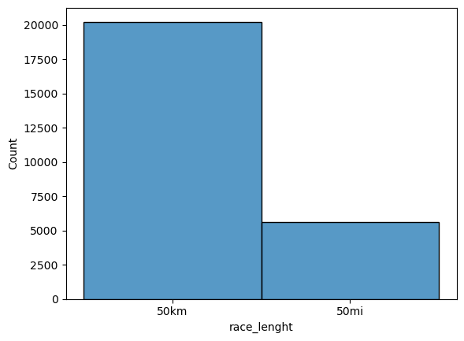

```python
sns.histplot(usa_races, x = 'race_lenght')
```

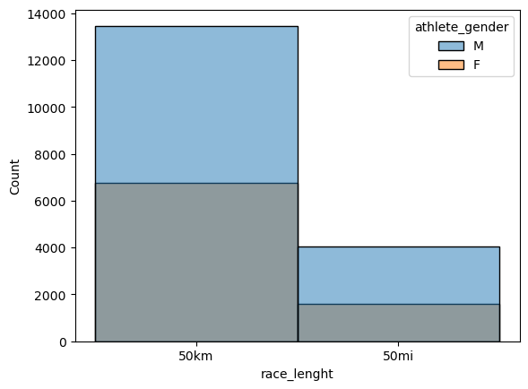

```python
sns.histplot(usa_races, x = 'race_lenght', hue = 'athlete_gender')
```

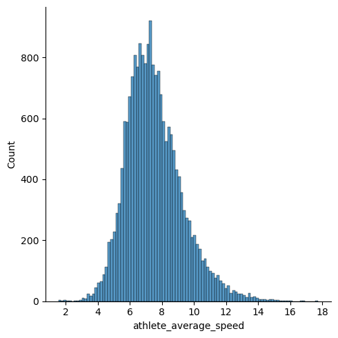

```python
# It's common for average speed in 50km race, to be around 6.5 to 7 per km
sns.displot(usa_races[usa_races['race_lenght']== '50km']['athlete_average_speed'])
```

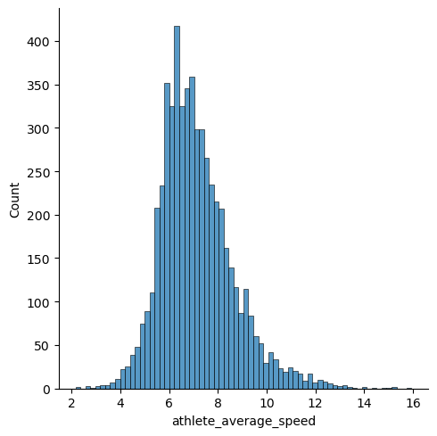

```python
sns.displot(usa_races[usa_races['race_lenght']== '50mi']['athlete_average_speed'])
```

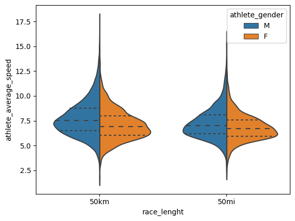

```python
sns.violinplot(data = usa_races, x='race_lenght', y= 'athlete_average_speed', hue= 'athlete_gender', split=True, inner='quart')
```

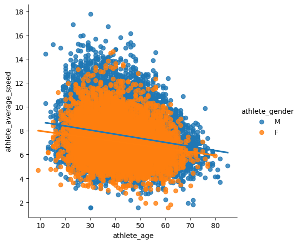

```python
sns.lmplot(data= usa_races, x= 'athlete_age', y= 'athlete_average_speed', hue= 'athlete_gender')
```

# Questions I want to find the answer

```python
usa_races['athlete_age'] = usa_races['athlete_age'].astype(int)
```

```python
usa_races.dtypes
```

```
race_date                    object
race_name                    object
race_lenght                  object
race_number_of_finishers      int64
athlete_id                    int64
athlete_gender               object
athlete_age                   int32
athlete_performance          object
athlete_average_speed       float64
dtype: object
```

```python
#race_date
#race_name
#race_lenght
#race_number_of_finishers
#athlete_performance
#athlete_club
#athlete_gender
#athlete_average_speed
#athlete_id
#athlete_age
```

# question 1: difference in speed for the 50km, Male vs Female

```python
usa_races.groupby(['race_lenght', 'athlete_gender'])['athlete_average_speed'].mean()
```

```
race_lenght  athlete_gender
50km         F                 7.083011
             M                 7.738985
50mi         F                 6.834371
             M                 7.257633
Name: athlete_average_speed, dtype: float64
```

# question 2: what age group are the best in the 50km race(20 + races min)

```python
usa_races.query('race_lenght == "50km"').groupby('athlete_age')['athlete_average_speed'].agg(['mean', 'count']).sort_values('mean', ascending=False).query('count>19')
```

| athlete_age | mean | count |
| --- | --- | --- |
| 20 | 8.712523 | 86 |
| 22 | 8.260221 | 113 |
| 21 | 8.129901 | 91 |
| 26 | 8.121561 | 310 |
| 23 | 8.061653 | 176 |
| 27 | 8.051917 | 324 |
| 32 | 7.998165 | 541 |
| 29 | 7.984435 | 439 |
| 24 | 7.982698 | 202 |
| 19 | 7.975195 | 41 |
| 28 | 7.965128 | 413 |
| 25 | 7.954669 | 275 |
| 30 | 7.891657 | 449 |
| 31 | 7.832432 | 458 |
| 35 | 7.830855 | 598 |
| 36 | 7.821363 | 634 |
| 33 | 7.805119 | 505 |
| 18 | 7.778030 | 33 |
| 34 | 7.765302 | 569 |
| 37 | 7.758824 | 717 |
| 38 | 7.684835 | 792 |
| 42 | 7.665644 | 689 |
| 39 | 7.652121 | 788 |
| 40 | 7.639355 | 769 |
| 41 | 7.546001 | 679 |
| 16 | 7.537150 | 20 |
| 44 | 7.473093 | 654 |
| 43 | 7.462091 | 690 |
| 48 | 7.423345 | 550 |
| 51 | 7.402175 | 532 |
| 55 | 7.345088 | 329 |
| 17 | 7.344808 | 26 |
| 46 | 7.306436 | 670 |
| 56 | 7.293745 | 306 |
| 49 | 7.276259 | 568 |
| 47 | 7.269876 | 589 |
| 45 | 7.267337 | 629 |
| 53 | 7.199968 | 401 |
| 52 | 7.167074 | 487 |
| 54 | 7.160447 | 394 |
| 50 | 7.124314 | 611 |
| 58 | 6.953215 | 247 |
| 59 | 6.940702 | 262 |
| 57 | 6.931184 | 326 |
| 60 | 6.879788 | 208 |
| 62 | 6.871537 | 160 |
| 64 | 6.836957 | 116 |
| 61 | 6.720148 | 189 |
| 63 | 6.656094 | 117 |
| 66 | 6.508108 | 74 |
| 65 | 6.464693 | 75 |
| 68 | 6.379146 | 48 |
| 73 | 6.365667 | 21 |
| 67 | 6.355094 | 53 |
| 69 | 6.174658 | 38 |
| 70 | 6.174400 | 20 |
| 71 | 6.072625 | 40 |

# question 3: what age group are the best in the 50mi race(20 + races min)

```python
usa_races.query('race_lenght == "50mi"').groupby('athlete_age')['athlete_average_speed'].agg(['mean', 'count']).sort_values('mean', ascending=False).query('count>19')
```

| athlete_age | mean | count |
| --- | --- | --- |
| 29 | 7.902252 | 135 |
| 23 | 7.779800 | 55 |
| 28 | 7.575252 | 107 |
| 30 | 7.569204 | 157 |
| 25 | 7.540923 | 91 |
| 31 | 7.451638 | 138 |
| 38 | 7.430022 | 231 |
| 35 | 7.422359 | 195 |
| 36 | 7.403854 | 185 |
| 26 | 7.379800 | 75 |
| 33 | 7.379188 | 149 |
| 22 | 7.367902 | 41 |
| 24 | 7.354274 | 73 |
| 42 | 7.327656 | 209 |
| 34 | 7.319011 | 182 |
| 40 | 7.310669 | 236 |
| 21 | 7.304658 | 38 |
| 20 | 7.293778 | 27 |
| 32 | 7.287969 | 162 |
| 39 | 7.283648 | 227 |
| 37 | 7.220493 | 221 |
| 27 | 7.201748 | 119 |
| 41 | 7.197017 | 179 |
| 45 | 7.130667 | 156 |
| 47 | 7.085410 | 156 |
| 44 | 7.052642 | 179 |
| 51 | 7.019379 | 124 |
| 46 | 6.897236 | 174 |
| 43 | 6.884225 | 187 |
| 52 | 6.847400 | 130 |
| 55 | 6.828623 | 69 |
| 54 | 6.805506 | 83 |
| 49 | 6.789553 | 159 |
| 57 | 6.783205 | 78 |
| 53 | 6.736969 | 96 |
| 56 | 6.708373 | 67 |
| 48 | 6.696853 | 136 |
| 59 | 6.672072 | 83 |
| 50 | 6.671541 | 172 |
| 64 | 6.620727 | 22 |
| 58 | 6.582328 | 67 |
| 63 | 6.514806 | 31 |
| 61 | 6.358355 | 31 |
| 62 | 6.272730 | 37 |
| 60 | 6.261788 | 33 |

# question 4: what age group are the worst in the 50km races(20 + races min)

```python
usa_races.query('race_lenght == "50km"').groupby('athlete_age')['athlete_average_speed'].agg(['mean', 'count']).sort_values('mean', ascending=True).query('count>19')
```

| athlete_age | mean | count |
| --- | --- | --- |
| 71 | 6.072625 | 40 |
| 70 | 6.174400 | 20 |
| 69 | 6.174658 | 38 |
| 67 | 6.355094 | 53 |
| 73 | 6.365667 | 21 |
| 68 | 6.379146 | 48 |
| 65 | 6.464693 | 75 |
| 66 | 6.508108 | 74 |
| 63 | 6.656094 | 117 |
| 61 | 6.720148 | 189 |
| 64 | 6.836957 | 116 |
| 62 | 6.871537 | 160 |
| 60 | 6.879788 | 208 |
| 57 | 6.931184 | 326 |
| 59 | 6.940702 | 262 |
| 58 | 6.953215 | 247 |
| 50 | 7.124314 | 611 |
| 54 | 7.160447 | 394 |
| 52 | 7.167074 | 487 |
| 53 | 7.199968 | 401 |
| 45 | 7.267337 | 629 |
| 47 | 7.269876 | 589 |
| 49 | 7.276259 | 568 |
| 56 | 7.293745 | 306 |
| 46 | 7.306436 | 670 |
| 17 | 7.344808 | 26 |
| 55 | 7.345088 | 329 |
| 51 | 7.402175 | 532 |
| 48 | 7.423345 | 550 |
| 43 | 7.462091 | 690 |
| 44 | 7.473093 | 654 |
| 16 | 7.537150 | 20 |
| 41 | 7.546001 | 679 |
| 40 | 7.639355 | 769 |
| 39 | 7.652121 | 788 |
| 42 | 7.665644 | 689 |
| 38 | 7.684835 | 792 |
| 37 | 7.758824 | 717 |
| 34 | 7.765302 | 569 |
| 18 | 7.778030 | 33 |
| 33 | 7.805119 | 505 |
| 36 | 7.821363 | 634 |
| 35 | 7.830855 | 598 |
| 31 | 7.832432 | 458 |
| 30 | 7.891657 | 449 |
| 25 | 7.954669 | 275 |
| 28 | 7.965128 | 413 |
| 19 | 7.975195 | 41 |
| 24 | 7.982698 | 202 |
| 29 | 7.984435 | 439 |
| 32 | 7.998165 | 541 |
| 27 | 8.051917 | 324 |
| 23 | 8.061653 | 176 |
| 26 | 8.121561 | 310 |
| 21 | 8.129901 | 91 |
| 22 | 8.260221 | 113 |
| 20 | 8.712523 | 86 |

# question 5: what age group are the worst in the 50mi races(20 + races min)

```python
usa_races.query('race_lenght == "50mi"').groupby('athlete_age')['athlete_average_speed'].agg(['mean', 'count']).sort_values('mean', ascending=True).query('count>19')
```

| athlete_age | mean | count |
| --- | --- | --- |
| 60 | 6.261788 | 33 |
| 62 | 6.272730 | 37 |
| 61 | 6.358355 | 31 |
| 63 | 6.514806 | 31 |
| 58 | 6.582328 | 67 |
| 64 | 6.620727 | 22 |
| 50 | 6.671541 | 172 |
| 59 | 6.672072 | 83 |
| 48 | 6.696853 | 136 |
| 56 | 6.708373 | 67 |
| 53 | 6.736969 | 96 |
| 57 | 6.783205 | 78 |
| 49 | 6.789553 | 159 |
| 54 | 6.805506 | 83 |
| 55 | 6.828623 | 69 |
| 52 | 6.847400 | 130 |
| 43 | 6.884225 | 187 |
| 46 | 6.897236 | 174 |
| 51 | 7.019379 | 124 |
| 44 | 7.052642 | 179 |
| 47 | 7.085410 | 156 |
| 45 | 7.130667 | 156 |
| 41 | 7.197017 | 179 |
| 27 | 7.201748 | 119 |
| 37 | 7.220493 | 221 |
| 39 | 7.283648 | 227 |
| 32 | 7.287969 | 162 |
| 20 | 7.293778 | 27 |
| 21 | 7.304658 | 38 |
| 40 | 7.310669 | 236 |
| 34 | 7.319011 | 182 |
| 42 | 7.327656 | 209 |
| 24 | 7.354274 | 73 |
| 22 | 7.367902 | 41 |
| 33 | 7.379188 | 149 |
| 26 | 7.379800 | 75 |
| 36 | 7.403854 | 185 |
| 35 | 7.422359 | 195 |
| 38 | 7.430022 | 231 |
| 31 | 7.451638 | 138 |
| 25 | 7.540923 | 91 |
| 30 | 7.569204 | 157 |
| 28 | 7.575252 | 107 |
| 23 | 7.779800 | 55 |
| 29 | 7.902252 | 135 |

# question 6:

```
                Best season for running--> Slower in summer than winter?

                 Spring 3-5
                 Summer 6-8
                 Fall 9-11
                 Winter 12-2
```

# Task 1:

```
        Create a month column, by extracting months from race_date column
```

```python
usa_races['race_month'] = usa_races['race_date'].str.split('.').str.get(1).astype(int)
```

```python
usa_races.head(25)
```

|  | race_date | race_name | race_lenght | race_number_of_finishers | athlete_id | athlete_gender | athlete_age | athlete_performance | athlete_average_speed | race_month |
| --- | --- | --- | --- | --- | --- | --- | --- | --- | --- | --- |
| 2539945 | 02.02.2020 | West Seattle Beach Run - Winter Edition | 50km | 20 | 71287 | M | 29 | 3:17:55 | 15.158 | 2 |
| 2539946 | 02.02.2020 | West Seattle Beach Run - Winter Edition | 50km | 20 | 629508 | M | 39 | 4:02:32 | 12.369 | 2 |
| 2539947 | 02.02.2020 | West Seattle Beach Run - Winter Edition | 50km | 20 | 64838 | M | 21 | 4:07:57 | 12.099 | 2 |
| 2539948 | 02.02.2020 | West Seattle Beach Run - Winter Edition | 50km | 20 | 704450 | M | 37 | 4:22:02 | 11.449 | 2 |
| 2539949 | 02.02.2020 | West Seattle Beach Run - Winter Edition | 50km | 20 | 810281 | M | 43 | 4:27:34 | 11.212 | 2 |
| 2539950 | 02.02.2020 | West Seattle Beach Run - Winter Edition | 50km | 20 | 810282 | F | 35 | 4:42:06 | 10.635 | 2 |
| 2539951 | 02.02.2020 | West Seattle Beach Run - Winter Edition | 50km | 20 | 11739 | M | 59 | 4:49:20 | 10.369 | 2 |
| 2539952 | 02.02.2020 | West Seattle Beach Run - Winter Edition | 50km | 20 | 80394 | M | 50 | 4:49:50 | 10.351 | 2 |
| 2539953 | 02.02.2020 | West Seattle Beach Run - Winter Edition | 50km | 20 | 140909 | F | 45 | 4:51:00 | 10.309 | 2 |
| 2539954 | 02.02.2020 | West Seattle Beach Run - Winter Edition | 50km | 20 | 753889 | M | 41 | 5:02:35 | 9.915 | 2 |
| 2539955 | 02.02.2020 | West Seattle Beach Run - Winter Edition | 50km | 20 | 810283 | F | 23 | 5:14:30 | 9.539 | 2 |
| 2539956 | 02.02.2020 | West Seattle Beach Run - Winter Edition | 50km | 20 | 810284 | F | 55 | 5:26:11 | 9.197 | 2 |
| 2539957 | 02.02.2020 | West Seattle Beach Run - Winter Edition | 50km | 20 | 40726 | M | 25 | 5:49:33 | 8.582 | 2 |
| 2539958 | 02.02.2020 | West Seattle Beach Run - Winter Edition | 50km | 20 | 708195 | F | 45 | 6:00:02 | 8.333 | 2 |
| 2539959 | 02.02.2020 | West Seattle Beach Run - Winter Edition | 50km | 20 | 73327 | F | 52 | 6:06:23 | 8.188 | 2 |
| 2539960 | 02.02.2020 | West Seattle Beach Run - Winter Edition | 50km | 20 | 48473 | F | 58 | 6:06:38 | 8.183 | 2 |
| 2539961 | 02.02.2020 | West Seattle Beach Run - Winter Edition | 50km | 20 | 150288 | M | 46 | 6:24:00 | 7.813 | 2 |
| 2539962 | 02.02.2020 | West Seattle Beach Run - Winter Edition | 50km | 20 | 53463 | M | 44 | 7:54:33 | 6.322 | 2 |
| 2539963 | 02.02.2020 | West Seattle Beach Run - Winter Edition | 50km | 20 | 11777 | F | 61 | 8:03:32 | 6.204 | 2 |
| 2539964 | 02.02.2020 | West Seattle Beach Run - Winter Edition | 50km | 20 | 11780 | M | 60 | 8:03:38 | 6.203 | 2 |
| 2541271 | 01.02.2020 | White Rock Classic 50K | 50km | 63 | 364678 | M | 54 | 4:25:09 | 11.314 | 2 |
| 2541272 | 01.02.2020 | White Rock Classic 50K | 50km | 63 | 347890 | M | 44 | 4:35:24 | 10.893 | 2 |
| 2541273 | 01.02.2020 | White Rock Classic 50K | 50km | 63 | 48096 | M | 27 | 4:47:32 | 10.434 | 2 |
| 2541274 | 01.02.2020 | White Rock Classic 50K | 50km | 63 | 54241 | F | 47 | 4:49:48 | 10.352 | 2 |
| 2541275 | 01.02.2020 | White Rock Classic 50K | 50km | 63 | 67094 | M | 35 | 4:53:00 | 10.239 | 2 |

# Task 2:

```
    Create a season column
             Spring 3-5
             Summer 6-8
             Fall 9-11
             Winter 12-2
```

# another way to create seasons column

def getSeason(race_season):

```
if (usa_races['race_season'] == 12 or usa_races['race_season'] == 1 or usa_races['race_season'] == 2):
    return "winter"
elif(usa_races['race_season'] == 3 or usa_races['race_season'] == 4 or usa_races['race_season'] == 5):
    return "spring"
elif(usa_races['race_season'] == 6 or usa_races['race_season'] == 7 or pusa_races['race_season'] == 8):
    return "summer"
else:
    return "fall"
```

```python
usa_races['race_season'] = usa_races['race_month'].apply(lambda x: 'winter' if x > 11 else 'fall' if x > 8 else 'summer' if x > 5 else 'spring' if x > 2  else 'winter')
```

```python
usa_races['race_season'].unique()
```

```
array(['winter', 'summer', 'spring', 'fall'], dtype=object)
```

```python
usa_races.groupby('race_season')['athlete_average_speed'].agg(['mean', 'count']).sort_values('mean', ascending=False)
```

| race_season | mean | count |
| --- | --- | --- |
| spring | 7.684430 | 3294 |
| winter | 7.518187 | 11595 |
| fall | 7.406619 | 8315 |
| summer | 6.869336 | 2653 |